# 2016 Iowa Liquor Sales Forecast

## By Brendan Bailey 3/28/17

### Executive Summary:

The Iowa State Liquor Board gave us a dataset of 2015 liquor sales in order to predict 2016 liquor sales. The data shows if there is a \$1 increase in Q1 Sales, total sales will increase by about \$4. Applying this model to 2016 Q1 sales, I estimate that Total Sales will be \$274 million plus or minus \$11.8 million dollars (between \$263 million and \$286 million). This is compared to \$283 million in sales for 2015. An increase in total sales is possible, but total sales for 2016 are more likely to decrease.

I recommend that the Iowa State Liquor Board refrain from raising liquor taxes, if the decision was predicated on an increase in total sales.

Below are the steps I took to come to this conclusion:

Importing relevant libraries below and reading in the dataset.

```python
#Data Description at https://data.iowa.gov/Economy/Iowa-Liquor-Sales/m3tr-qhgy

import pandas as pd
import numpy as np
import seaborn as sns
import matplotlib.pyplot as plt
from sklearn import linear_model
from sklearn.model_selection import train_test_split
from sklearn.model_selection import cross_val_score, cross_val_predict
from sklearn import metrics
import statsmodels.api as sm
from statsmodels.stats.outliers_influence import variance_inflation_factor
iowa_data = pd.read_csv("Iowa_Liquor_sales_reduced.csv")
```

Peforming exploratory data analysis on the data. There are several issues with the data:

- Column names have spaces and parentheses in them which makes it difficult calling them as attributes
- A lot of null values for County and Category Name
- Date, Sales, Volume, and Bottles Sold all are interpreted as strings
- 2,987 duplicates within the dataset

```python
def eda(dataframe): #Performs exploratory data analysis on the dataframe
    print "columns \n", dataframe.columns
    print "head \n", dataframe.head()
    print "tail \n", dataframe.tail()
    print "missing values \n", dataframe.isnull().sum()
    print "dataframe types \n", dataframe.dtypes
    print "dataframe shape \n", dataframe.shape
    print "dataframe describe \n", dataframe.describe() #summary statistics
    for item in dataframe:
        print item
        print dataframe[item].nunique()
    print "%s duplicates out of %s records" % (len(dataframe) - len(dataframe.drop_duplicates()), len(dataframe))
eda(iowa_data)
```

```
columns
Index([u'Date', u'Store Number', u'City', u'Zip Code', u'County Number',
       u'County', u'Category', u'Category Name', u'Vendor Number',
       u'Item Number', u'Item Description', u'Bottle Volume (ml)',
       u'State Bottle Cost', u'State Bottle Retail', u'Bottles Sold',
       u'Sale (Dollars)', u'Volume Sold (Liters)', u'Volume Sold (Gallons)'],
      dtype='object')
head
         Date  Store Number         City Zip Code  County Number      County  \
0  03/31/2016          5029    DAVENPORT    52806           82.0       Scott
1  03/31/2016          5029    DAVENPORT    52806           82.0       Scott
2  03/31/2016          4959  CEDAR FALLS    50613            7.0  Black Hawk
3  03/31/2016          2190   DES MOINES    50314           77.0        Polk
4  03/31/2016          5240  WEST BRANCH    52358            NaN         NaN

    Category       Category Name  Vendor Number  Item Number  \
0  1022100.0             TEQUILA            370        87152
1  1022100.0             TEQUILA            395        89197
2  1071100.0  AMERICAN COCKTAILS            380        63959
3  1031200.0      VODKA FLAVORED            205        40597
4  1081200.0      CREAM LIQUEURS            305        73055

                        Item Description  Bottle Volume (ml)  \
0                           Avion Silver                 375
1  Jose Cuervo Especial Reposado Tequila                1000
2         Uv Blue Raspberry Lemonade Pet                1750
3                New Amsterdam Red Berry                 200
4                               Rumchata                 750

  State Bottle Cost State Bottle Retail  Bottles Sold Sale (Dollars)  \
0             $9.99              $14.99            12        $179.88
1            $12.50              $18.75             2         $37.50
2             $5.97               $8.96             6         $53.76
3             $2.24               $3.36            48        $161.28
4            $12.50              $18.75             6        $112.50

   Volume Sold (Liters)  Volume Sold (Gallons)
0                   4.5                   1.19
1                   2.0                   0.53
2                  10.5                   2.77
```

[output cut: 138 more lines]

```
Bottle Volume (ml)
34
State Bottle Cost
1471
State Bottle Retail
1525
Bottles Sold
275
Sale (Dollars)
11456
Volume Sold (Liters)
544
Volume Sold (Gallons)
538
2987 duplicates out of 2709552 records
```

Most of the problems fixed by the function below. Made some progress with the county data by filling about 60% of its null values. Unfortunately, trying to fill Category Name did not work.

```python
def clean_iowa_data(df): #Cleans Dataframe - fills nulls, eliminates dupes, converts data types
    #Replacing spaces with underscores and deleting parentheses in column names
    df.columns = [column.replace(" ", "_").replace("(","").replace(")","") for column in df.columns]

    #Elimininating Duplicate Data
    df.drop_duplicates(inplace = True)

    #Third try at imputing empty data - 428 Nulls for County in 10% dataset!
    temp_df = iowa_data[["Store_Number", "County"]].dropna().drop_duplicates()
    temp_df.rename(columns = {"County": "Full_County"}, inplace = True)
    assert max(temp_df.groupby('Store_Number').Full_County.count()) == 1
    df = pd.merge(df, temp_df, how = "left", left_on = "Store_Number", right_on = "Store_Number")

    #Third try at imputing empty data - 0 improvement for Category Name on 10% dataset. Maybe increase improvement on full?
    temp_df = iowa_data[["Category", "Category_Name"]].dropna().drop_duplicates()
    temp_df.rename(columns = {"Category_Name": "Full_Category_Name"}, inplace = True)
    assert max(temp_df.groupby('Category').Full_Category_Name.count()) == 1
    df = pd.merge(df, temp_df, how = "left", left_on = "Category", right_on = "Category")

    #Converting column types
    df["Date"] = pd.to_datetime(df.Date)
    df["Sale_Dollars"] = df["Sale_Dollars"].replace( '[\$,)]','', regex=True ).astype(float)
    df["State_Bottle_Retail"] = df["State_Bottle_Retail"].replace( '[\$,)]','', regex=True ).astype(float) #http://stackoverflow.com/questions/31521526/pandas-column-convert-currency-to-float
    df["State_Bottle_Cost"] = df["State_Bottle_Cost"].replace( '[\$,)]','', regex=True ).astype(float)
    return df

iowa_data = clean_iowa_data(iowa_data)
eda(iowa_data)
```

```
columns
Index([u'Date', u'Store_Number', u'City', u'Zip_Code', u'County_Number',
       u'County', u'Category', u'Category_Name', u'Vendor_Number',
       u'Item_Number', u'Item_Description', u'Bottle_Volume_ml',
       u'State_Bottle_Cost', u'State_Bottle_Retail', u'Bottles_Sold',
       u'Sale_Dollars', u'Volume_Sold_Liters', u'Volume_Sold_Gallons',
       u'Full_County', u'Full_Category_Name'],
      dtype='object')
head
        Date  Store_Number         City Zip_Code  County_Number      County  \
0 2016-03-31          5029    DAVENPORT    52806           82.0       Scott
1 2016-03-31          5029    DAVENPORT    52806           82.0       Scott
2 2016-03-31          4959  CEDAR FALLS    50613            7.0  Black Hawk
3 2016-03-31          2190   DES MOINES    50314           77.0        Polk
4 2016-03-31          5240  WEST BRANCH    52358            NaN         NaN

    Category       Category_Name  Vendor_Number  Item_Number  \
0  1022100.0             TEQUILA            370        87152
1  1022100.0             TEQUILA            395        89197
2  1071100.0  AMERICAN COCKTAILS            380        63959
3  1031200.0      VODKA FLAVORED            205        40597
4  1081200.0      CREAM LIQUEURS            305        73055

                        Item_Description  Bottle_Volume_ml  State_Bottle_Cost  \
0                           Avion Silver               375               9.99
1  Jose Cuervo Especial Reposado Tequila              1000              12.50
2         Uv Blue Raspberry Lemonade Pet              1750               5.97
3                New Amsterdam Red Berry               200               2.24
4                               Rumchata               750              12.50

   State_Bottle_Retail  Bottles_Sold  Sale_Dollars  Volume_Sold_Liters  \
0                14.99            12        179.88                 4.5
1                18.75             2         37.50                 2.0
2                 8.96             6         53.76                10.5
3                 3.36            48        161.28                 9.6
4                18.75             6        112.50                 4.5

   Volume_Sold_Gallons Full_County  Full_Category_Name
0                 1.19       Scott             TEQUILA
1                 0.53       Scott             TEQUILA
```

[output cut: 147 more lines]

```
State_Bottle_Retail
1525
Bottles_Sold
275
Sale_Dollars
11456
Volume_Sold_Liters
544
Volume_Sold_Gallons
538
Full_County
99
Full_Category_Name
73
0 duplicates out of 2706565 records
```

To make the predictions of sales by store, we need to aggregate the data at the store level. Since we will be making predictions on Q1 data, variables specifically regarding Q1 were created.

There were some stores that did not have any 2015 Q1 sales in the 10% dataset, so I imputed the county average. However, that didn't seem to be a problem in the full dataset.

Data is also separated by year because we will be training and testing the model on the 2015 data and making predictions on the 2016 data.

Deduplicating by store number is an additional step taken to clean the data, as there are duplicates with slightly different geographic information.

```python
def transform_data(df, year): #Transforms the DataFrame so it has aggregates at the Store Level
    base_df = df[df.Date.dt.year == year] #Selects the appropriate year
    master_df = base_df[["Store_Number", "City", "Zip_Code", "Full_County"]].drop_duplicates() #Adding Geographic Information

    group_by_list = ["Sale_Dollars", "Volume_Sold_Liters", "Bottles_Sold"] #Adding Summable Info
    for column in group_by_list:
        temp_df = base_df.groupby('Store_Number')[column].sum().to_frame()
        master_df = pd.merge(master_df, temp_df, how = "left", left_on = "Store_Number", right_index = True)

    group_by_list = ["State_Bottle_Cost", "State_Bottle_Retail"] #Adding Average Info
    for column in group_by_list:
        temp_df = base_df.groupby('Store_Number')[column].mean().to_frame()
        master_df = pd.merge(master_df, temp_df, how = "left", left_on = "Store_Number", right_index = True)

    group_by_list = ["Sale_Dollars", "Volume_Sold_Liters", "Bottles_Sold"] #Adding January through March Sales Data
    for column in group_by_list:
        temp_df = base_df[base_df.Date.dt.month.isin([1,2,3])]
        temp_df = temp_df.groupby('Store_Number')[column].sum()
        temp_df.name = "Jan_Mar_%s" % column
        temp_df = temp_df.to_frame()
        master_df = pd.merge(master_df, temp_df, how = "left", left_on = "Store_Number", right_index = True)

        #Filling in Nulls for Jan Mar Data with County Average
        temp_df = master_df.groupby("Full_County")["Jan_Mar_%s" % column].mean()
        temp_df.name = "Jan_Mar_Cty_Avg_%s" % column
        temp_df = temp_df.to_frame()
        master_df = pd.merge(master_df, temp_df, how = "left", left_on = "Full_County", right_index = True)
        master_df["Jan_Mar_%s" % column].fillna(master_df["Jan_Mar_Cty_Avg_%s" % column], inplace = True)

    #Add Interaction for Jan Mar Sales Dollars and Jan Mar Volume Sold Liters
    master_df["Sales_Liters_Interaction"] = master_df["Sale_Dollars"] * master_df["Volume_Sold_Liters"]

    #Get County Dummies
    master_df.reset_index(inplace = True)
    temp_df = pd.get_dummies(master_df.Full_County)
    master_df = pd.merge(master_df, temp_df, how = "left", left_index = True, right_index = True)

    master_df.drop_duplicates(subset = "Store_Number", inplace = True) #Some Store Numbers are duplicated due to minor differences in location data
    return master_df

data_2015 = transform_data(iowa_data, 2015)
```

I did notice store 2633 is an outlier in the amount of sales they made, making $9.8 million in sales. It did sell the most for that year, so maybe it is just a high volume store that has contracts with major venues. Because of this I left them in the dataset.

```python
print max(data_2015.Sale_Dollars)
print data_2015[data_2015.Sale_Dollars == max(data_2015.Sale_Dollars)]["Store_Number"]
print max(data_2015.Volume_Sold_Liters)
print data_2015[data_2015.Volume_Sold_Liters == max(data_2015.Volume_Sold_Liters)]["Store_Number"]
```

```
9837698.17
40    2633
Name: Store_Number, dtype: int64
582748.11
40    2633
Name: Store_Number, dtype: int64
```

Sales does not appear to be normally distributed or it at least has a number of high outliers. I think it's hard to achieve a real normal distribution because sales has a hard stop at $0.

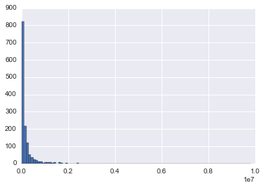

```python
%matplotlib inline
plt.hist(data_2015.Sale_Dollars, bins = 100)
```

My initial set of variables were Q1 Sales, Q1 Volume Sold, Q1 Bottles Sold, and whether they were in Polk, Linn, or Black Hawk County (the top 3 counties for liquor most liquor transactions according to the 10% dataset). The county dummy variables were proven insignficant so they were thrown out.

Additionally, Q1 Volume Sold and Q1 Bottles Sold had a high variable inflation factor, so I threw those out too because I didn't want a multicollinearity problem.

I kept Q1 Sales and didn't seek any additional variables because with just Q1 Sales, I achieved a 0.97 R-Squared. I think this keeps in line with Ockham's Razor where we should pick a simple model over a complicated one.

```
(962, 1) (962,)
(413, 1) (413,)
Cross-Predicted Accuracy: 0.967990440629
                            OLS Regression Results
==============================================================================
Dep. Variable:           Sale_Dollars   R-squared:                       0.969
Model:                            OLS   Adj. R-squared:                  0.969
Method:                 Least Squares   F-statistic:                 2.991e+04
Date:                Wed, 29 Mar 2017   Prob (F-statistic):               0.00
Time:                        10:39:18   Log-Likelihood:                -12406.
No. Observations:                 962   AIC:                         2.482e+04
Df Residuals:                     960   BIC:                         2.483e+04
Df Model:                           1
Covariance Type:            nonrobust
========================================================================================
                           coef    std err          t      P>|t|      [0.025      0.975]
----------------------------------------------------------------------------------------
const                -1251.6829   3350.106     -0.374      0.709   -7826.058    5322.692
Jan_Mar_Sale_Dollars     4.2166      0.024    172.935      0.000       4.169       4.264
==============================================================================
Omnibus:                      536.847   Durbin-Watson:                   2.041
Prob(Omnibus):                  0.000   Jarque-Bera (JB):            43765.765
Skew:                           1.669   Prob(JB):                         0.00
Kurtosis:                      35.874   Cond. No.                     1.48e+05
==============================================================================

Warnings:
[1] Standard Errors assume that the covariance matrix of the errors is correctly specified.
[2] The condition number is large, 1.48e+05. This might indicate that there are
strong multicollinearity or other numerical problems.
VIF: [1.1562348478567208, 1.0000000000000004]
```

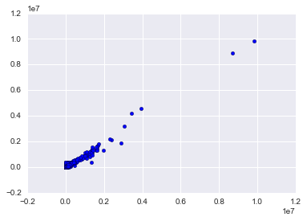

```python
def create_linear_model(features, target, seed):
    X_train, X_test, y_train, y_test = train_test_split(features, target, test_size=0.3, random_state = seed)
    print X_train.shape, y_train.shape
    print X_test.shape, y_test.shape
    lm = linear_model.LinearRegression()
    model = lm.fit(X_train, y_train)
    i = 10
    scores = cross_val_score(model, X_train, y_train, cv=i)
    # Make cross validated predictions
    predictions = cross_val_predict(model, X_train, y_train, cv=i)
    plt.scatter(y_train, predictions)
    accuracy = metrics.r2_score(y_train, predictions)
    print "Cross-Predicted Accuracy:", accuracy
    #Getting Stats Models Summary
    X_train_sm = sm.add_constant(X_train)
    sm_model = sm.OLS(y_train, X_train_sm).fit()
    print sm_model.summary()
    vif = [variance_inflation_factor(X_train_sm.values, ix) for ix in range(X_train_sm.shape[1])] #Incredibly high VIF :(
    print "VIF:", vif
    return X_train, X_test, y_train, y_test, lm
test_variables = ["Jan_Mar_Sale_Dollars"] #Doing just Jan_Mar_Sales doesn't change outcome very much
X_train, X_test, y_train, y_test, lm = create_linear_model(data_2015[test_variables], data_2015.Sale_Dollars, 61629)
```

In testing the model against the 30% holdout, we received at 0.95 R-Squared. So the model should be good.

```
Accuracy: 0.952166108838
```

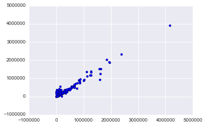

```python
def test_model(x, y, model):
    #Testing Model
    test_predictions = model.predict(x)
    plt.scatter(y_test, test_predictions)
    accuracy = metrics.r2_score(y, test_predictions)
    print "Accuracy:", accuracy
test_model(X_test, y_test, lm)
```

I did a regularized model because the instructions asked us to. But since I'm only using one predictor, I'm not sure if it will be useful in this case.

```
Sample with regularization: 0.968898379572
```

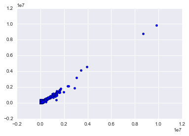

```python
#Ridge Regression - R2 does not change with regularization
ridge_lm = linear_model.RidgeCV(alphas=[0.1, 1, 10]) # Try different alphas
ridge_model = ridge_lm.fit(X_train, y_train)
ridge_predictions = ridge_model.predict(X_train)
print "Sample with regularization:", ridge_model.score(X_train, y_train)
plt.scatter(y_train, ridge_predictions)
```

```
Accuracy: 0.952173944825
```

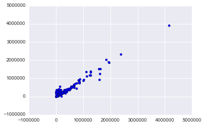

```python
test_model(X_test, y_test, ridge_model)
```

In using my model against the full dataset, my model overestimates Liquor Sales by about $2 million dollars or 0.6% Difference.

```python
#Full Model
full_predictions = lm.predict(data_2015[test_variables])
Prediction_2015 = sum(full_predictions)
Actual_2015 = data_2015["Sale_Dollars"].sum()
print "2015 Prediction:", Prediction_2015
print "2015 Actual:", Actual_2015
print "Difference:", Prediction_2015 - Actual_2015
print "% Difference:", (Prediction_2015 - Actual_2015)/Actual_2015 * 100
```

```
2015 Prediction: 285677945.767
2015 Actual: 283944590.04
Difference: 1733355.7271
% Difference: 0.610455626872
```

Using the low and high versions of the coefficients from the stats model report, I am creating what the low and high end predictions will be for 2016 alcohol sales.

```python
low_intercept = -7826.058
low_coef = 4.169
low_prediction = sum([x*low_coef + low_intercept for x in data_2015.Jan_Mar_Sale_Dollars])

high_intercept = 5322.692
high_coef = 4.264
high_prediction = sum([x*high_coef + high_intercept for x in data_2015.Jan_Mar_Sale_Dollars])
print "95% Confidence Interval:", low_prediction, high_prediction
```

```
95% Confidence Interval: 273392442.877 297947042.704
```

Plugging the 2016 Q1 Sales Data into the model it looks like 2016's total data will be \$274 million plus or minus \$11.8 million dollars. So the estimated range is between \$263 million and \$286 million. An increase above 2015's \$283 million is possible, but total sales for 2016 are more likely to decrease.

```python
data_2016 = transform_data(iowa_data, 2016)
predictions_2016 = lm.predict(data_2016[test_variables])
Prediction_2016 = sum(predictions_2016)
print "2016 Prediction:", Prediction_2016
```

```
2016 Prediction: 274321491.87
```

```python
low_intercept = -7826.058
low_coef = 4.169
low_prediction = sum([x*low_coef + low_intercept for x in data_2016.Jan_Mar_Sale_Dollars])

high_intercept = 5322.692
high_coef = 4.264
high_prediction = sum([x*high_coef + high_intercept for x in data_2016.Jan_Mar_Sale_Dollars])
print "95% Confidence Interval:", low_prediction, high_prediction
print Prediction_2016 - low_prediction
print high_prediction - Prediction_2016
```

```
95% Confidence Interval: 262526611.053 286100618.938
11794880.817
11779127.0681
```

Appendix: Below are some graphs generated for class presentation purposes. The first graph compares 2015 and 2016 sales. The only data for 2016 is Q1 Data, so the rest of the data is left blank.

```python
#Making a Stacked Bar Graph to compare 2015 and 2016 revenues
data_2015["year"] = 2015
data_2016["year"] = 2016
data_2015["Rest of Year"] = data_2015["Sale_Dollars"] - data_2015["Jan_Mar_Sale_Dollars"]
data_2016["Rest of Year"] = data_2016["Sale_Dollars"] - data_2016["Jan_Mar_Sale_Dollars"]
plt_2015 = data_2015[["year", "Jan_Mar_Sale_Dollars", "Rest of Year"]]
plt_2016 = data_2016[["year", "Jan_Mar_Sale_Dollars", "Rest of Year"]]
plt_frame = pd.concat([plt_2015, plt_2016])
plt_frame.columns = ["year", "Q1 Sales", "Rest of Year"]
plt_frame["Q1 Sales"] = plt_frame["Q1 Sales"]/1000000
plt_frame["Rest of Year"] = plt_frame["Rest of Year"]/1000000
```

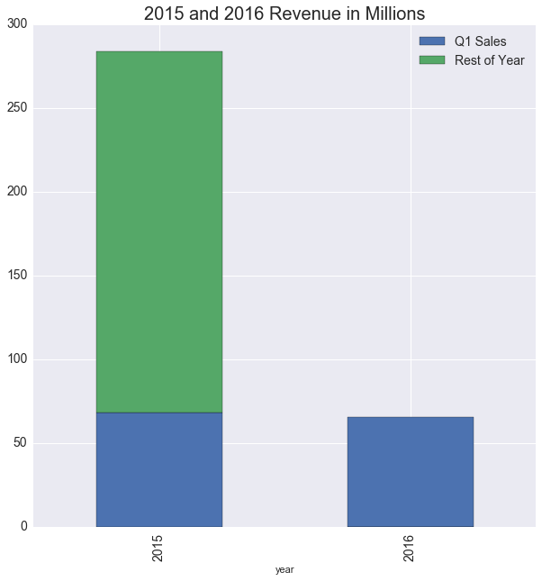

```python
stacked_bar = plt_frame.groupby('year').sum().plot(kind='bar', stacked=True, figsize = (10,10), style = "ggplot", fontsize = 14).get_yaxis().get_major_formatter().set_scientific(False)
plt.title("2015 and 2016 Revenue in Millions", fontsize = 20)
plt.legend(fontsize = 14)
```

Recreating above graph with Predicted Value. The orange lines symbolize the low and high estimates for 2016 Sales.

```python
plt_frame2 = plt_frame.groupby('year').sum()
Q1_2016 = plt_frame2[plt_frame2.index == 2016]["Q1 Sales"]
plt_frame2.loc[plt_frame2.index == 2016,"Rest of Year"] = Prediction_2016/1000000 - Q1_2016
plt_frame2
```

| year | Q1 Sales | Rest of Year |
| --- | --- | --- |
| 2015 | 68.158617 | 215.785973 |
| 2016 | 65.449030 | 208.872461 |

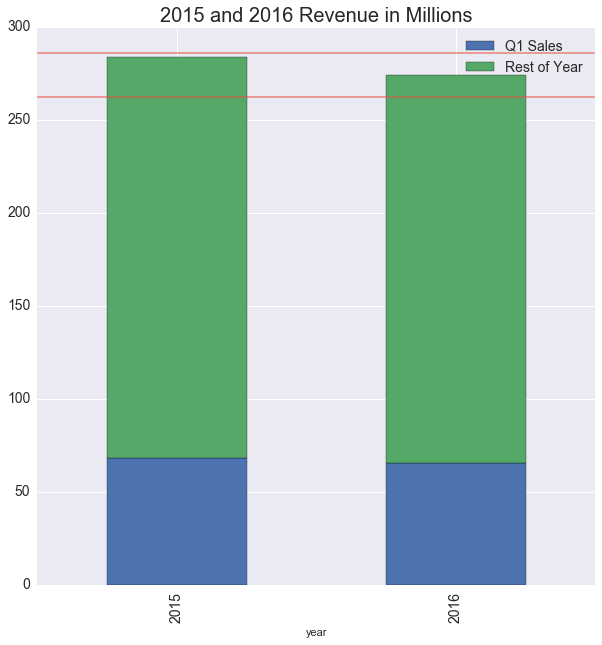

```python
stacked_frame2 = plt_frame2.groupby(plt_frame2.index).sum().plot(kind='bar', stacked=True, figsize = (10,10), style = "ggplot", fontsize = 14).get_yaxis().get_major_formatter().set_scientific(False)
plt.title("2015 and 2016 Revenue in Millions", fontsize = 20)
plt.legend(fontsize = 14)
plt.axhline(low_prediction/1000000, color='#eb4e39', linewidth=2, alpha = 0.5)
plt.axhline(high_prediction/1000000, color='#eb4e39', linewidth=2, alpha = 0.5)
```